# (Analysis of Ford GoBike System Data )

## by (Abrar EL-Mogy)

## Investigation Overview

> We are interested to know When are the most trips taken? Also what effects the duration of the trips?

## Dataset Overview

> **Ford GoBike** dataset includes information about individual rides during February 2019.

## (Visualization 1)

> Let's see an overview about our data!

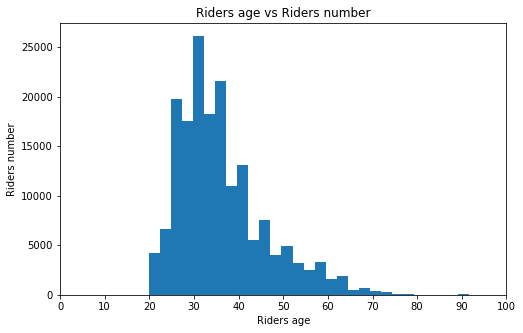

> Here, we can find that the age of majority of the riders is 30 years.

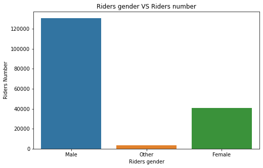

> Here, we can see that the majority of the riders are males.

## (Visualization 2)

> Let's see what affects our rides duration!

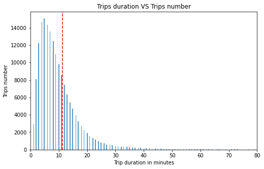

> Here, we can see that the average of the trips is around 10 mins but the strange is that there are some trips between 20 and 80 mins which is a very long duration.

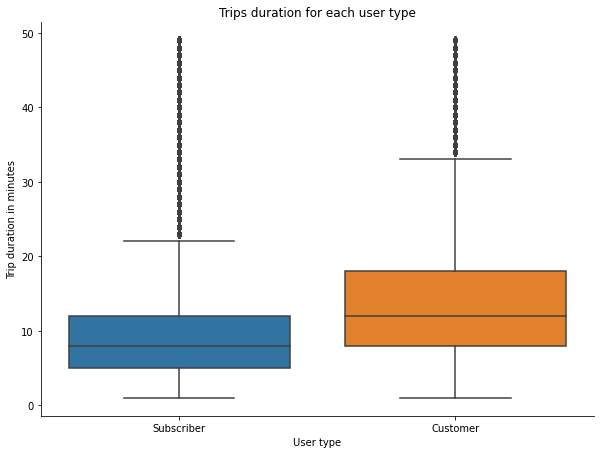

> Subscribers using bikes for short trips compared with the customers.

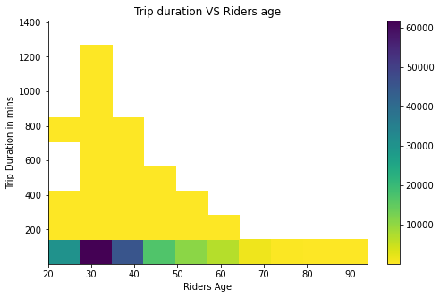

> Here, we can say that the riders with age between 20 and 40 years have the longest rides, which is expected.

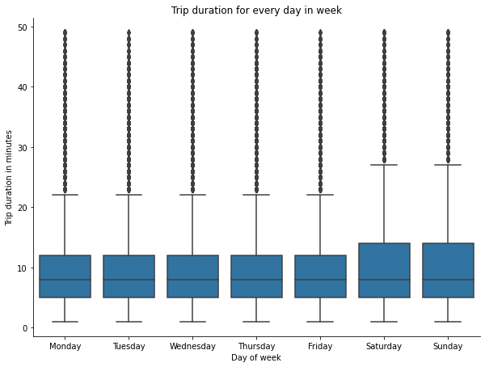

> Here, we can see that Weekends **[Sunday and Saturday]** have the longest trip.

### Let's summrize our findings regarding the trip duration:

**The duration of the trip depends on:**

1. The age, the younger the age, the longer the trip.
2. The day of week, the longest trip took part in weekends.
3. The user type, subscribers are using bikes for short trips compared with the customers.

## (Visualization 3)

> Let's see When are the most trips taken!

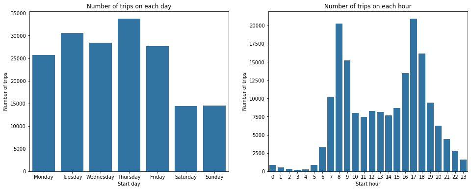

> We can see that **Saturday** and **Sunday** are the least busy days which is logical as these days are considers as vacation days.

> Also we can find that the busiest hours are **8 am** and **5 pm**, as these hours considers as working hours/rush hours.

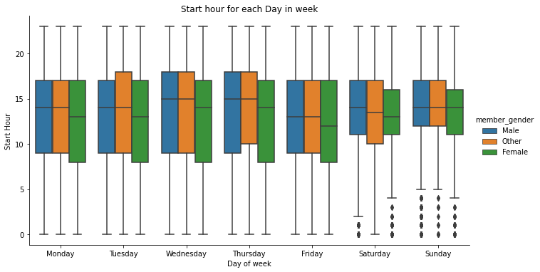

> Here, we can see that on weekends the trips start late compared to weekdays and females are starting slightly early than the males.

### Let's Summrize When the most trips are taken!

**Trips time depends on:**

1. Starting hours slightly depend on member gender, as females are starting slightly early than the males and the busiest hours are **8 am** and **5 pm**
2. The day of week, Saturday and Sunday are the least busy.

## Analysis Summary:

> We can say that subscribers from males and females are using this service as work transportaion, as the duration of the trips are short and the most taken trips are in weedays not weekends, and on weekends the trips starts late, also the most using hours are 8 am and 5pm which considered as working hours.